# Lab 01

V. Markos

2026-10-20

# Introduction

In `ESS11e04_2/ESS11e04_2.csv` you can find a (large) dataset from a social study conducted throughout the EU. More information can be found [here](https://ess.sikt.no/en/datafile/242aaa39-3bbb-40f5-98bf-bfb1ce53d8ef?tab=0&elems=4cfef379-934d-41e6-8c3c-4b77f9d91232). You can also find more on the variables, and many descriptive statistics in `ESS11e04_2 codebook.html` (open in any browser).

We are going to work with those data to showcase some (mostly) descriptive statistics manipulations using R.

## Simple Hypothesis Testing

First, reload the dataset:

```r
ess_pol <- read.csv('ess_pol.csv', sep = ',')
summary(ess_pol)
```

```
##        X           ess_data.cntry  ess_data.nwspol ess_data.netusoft
##  Min.   :    1   Length   :50116   Min.   :   0    Min.   :1.000
##  1st Qu.:12530   N.unique :   30   1st Qu.:  30    1st Qu.:4.000
##  Median :25059   N.blank  :    0   Median :  60    Median :5.000
##  Mean   :25059   Min.nchar:    2   Mean   : 229    Mean   :4.202
##  3rd Qu.:37587   Max.nchar:    2   3rd Qu.: 120    3rd Qu.:5.000
##  Max.   :50116                     Max.   :9999    Max.   :9.000
##  ess_data.netustm ess_data.ppltrst
##  Min.   :   0     Min.   : 0.000
##  1st Qu.: 120     1st Qu.: 3.000
##  Median : 240     Median : 5.000
##  Mean   :1706     Mean   : 5.211
##  3rd Qu.: 660     3rd Qu.: 7.000
##  Max.   :9999     Max.   :99.000
```

Let us also review the aggregate distribution of all those variables per country:

```r
aggregate(ess_pol, by = list(ess_pol$ess_data.cntry), FUN = mean)
```

[output not shown]

```
##    Group.1       X ess_data.cntry ess_data.nwspol ess_data.netusoft
## 1       AT  1177.5             NA        55.56669          4.143585
## 2       BE  3151.5             NA       110.16876          4.537014
## 3       BG  5068.0             NA       160.66994          3.804377
## 4       CH  6879.5             NA        73.68569          4.545520
## 5       CY  7914.0             NA       116.79124          3.816058
## 6       DE  9466.5             NA       244.47314          4.482645
## 7       EE 11323.0             NA       213.71230          4.594741
## 8       ES 12891.5             NA        95.74729          4.287961
## 9       FI 14595.0             NA        92.65579          4.592450
## 10      FR 16262.0             NA       145.26708          4.331451
## 11      GB 17989.5             NA       264.16211          4.382423
## 12      GR 20210.0             NA       100.42836          4.120421
## 13      HR 22370.0             NA       374.12220          3.844530
## 14      HU 24210.5             NA       331.38952          3.872993
```

[output cut: 47 more lines]

The wrong way to proceed at this stage is to use a t-test to compare, say, Austria with Belgium, in terms of time devoted into politics related news:

```r
# THIS IS WRONG!
austria <- ess_pol[ess_pol$ess_data.cntry == 'AT', ]
belgium <- ess_pol[ess_pol$ess_data.cntry == 'BE', ]
t.test(austria$ess_data.nwspol, belgium$ess_nwspol)
```

```
##
##  One Sample t-test
##
## data:  austria$ess_data.nwspol
## t = 10.21, df = 2353, p-value < 2.2e-16
## alternative hypothesis: true mean is not equal to 0
## 95 percent confidence interval:
##  44.89396 66.23943
## sample estimates:
## mean of x
##  55.56669
```

The first error here is that we have not cleaned our data, i.e., we have not dropped any dummy values. For example, as one reads here, 9999 for example, in `nwspol` means that no answer was provided, while 8888 and 7777 also have a meaning. So, one first approach might be:

```r
austria <- austria[!(austria$ess_data.nwspol %in% c(7777,8888,9999)) , ]
summary(austria)
```

```
##        X            ess_data.cntry ess_data.nwspol   ess_data.netusoft
##  Min.   :   1.0   Length   :2352   Min.   :   0.00   Min.   :1.000
##  1st Qu.: 588.8   N.unique :   1   1st Qu.:  15.00   1st Qu.:4.000
##  Median :1176.5   N.blank  :   0   Median :  30.00   Median :5.000
##  Mean   :1176.9   Min.nchar:   2   Mean   :  48.06   Mean   :4.146
##  3rd Qu.:1765.2   Max.nchar:   2   3rd Qu.:  60.00   3rd Qu.:5.000
##  Max.   :2354.0                    Max.   :1200.00   Max.   :5.000
##  ess_data.netustm ess_data.ppltrst
##  Min.   :   0     Min.   : 0.000
##  1st Qu.:  90     1st Qu.: 5.000
##  Median : 180     Median : 6.000
##  Mean   :1672     Mean   : 5.882
##  3rd Qu.: 600     3rd Qu.: 7.000
##  Max.   :8888     Max.   :10.000
```

Now we observe that there is at least one participant that devotes 1200 minutes (20 hours) per day on politics news. Since this might be a mistyped value, we might impose a seemingly artificial but, more or less, sound limit, e.g., by filtering out extreme values, too.

In our case, we first examine how many such extremities occur:

```r
length(austria[austria$ess_data.nwspol > 600, ])
```

```
## [1] 6
```

Since there are not that many extreme values, our choice does not make any substantial difference, so we might decide to keep those observations too. We now proceed to clean Belgium data too:

```r
belgium <- belgium[!(belgium$ess_data.nwspol %in% c(7777,8888,9999)) , ]
summary(belgium)
```

```
##        X          ess_data.cntry ess_data.nwspol   ess_data.netusoft
##  Min.   :2355   Length   :1590   Min.   :   0.00   Min.   :1.000
##  1st Qu.:2752   N.unique :   1   1st Qu.:  30.00   1st Qu.:5.000
##  Median :3152   N.blank  :   0   Median :  60.00   Median :5.000
##  Mean   :3151   Min.nchar:   2   Mean   :  86.69   Mean   :4.536
##  3rd Qu.:3549   Max.nchar:   2   3rd Qu.:  90.00   3rd Qu.:5.000
##  Max.   :3948                    Max.   :1196.00   Max.   :5.000
##  ess_data.netustm ess_data.ppltrst
##  Min.   :   0     Min.   : 0.000
##  1st Qu.: 120     1st Qu.: 4.000
##  Median : 240     Median : 6.000
##  Mean   :1045     Mean   : 5.596
##  3rd Qu.: 480     3rd Qu.: 7.000
##  Max.   :8888     Max.   :88.000
```

Let us again count extreme values:

```r
length(belgium[belgium$ess_data.nwspol > 600, ])
```

```
## [1] 6
```

Again, we keep those as well. In case the extreme values for Belgians were far too many, we might have needed to revise our choice for Austria, too.

Now, we feel (are we?) ready to perform a better t-test:

```r
t.test(austria$ess_data.nwspol, belgium$ess_data.nwspol)
```

```
##
##  Welch Two Sample t-test
##
## data:  austria$ess_data.nwspol and belgium$ess_data.nwspol
## t = -9.5828, df = 1898.8, p-value < 2.2e-16
## alternative hypothesis: true difference in means is not equal to 0
## 95 percent confidence interval:
##  -46.53906 -30.72606
## sample estimates:
## mean of x mean of y
##  48.05612  86.68868
```

So, again, we get the same result with quite a lot of confidence ($p<10^{-15}$), that is, the probability of Type I error is:

$$p<0.000000000000001$$
Again, are we allowed to use a t-test here? To use a t-test, we assume:

- at first, that both populations are normally distributed, and;
- no knowledge of population SD.

The second hypothesis if fulfilled but what about the first one?

The first step might be to plot the actual distribution, i.e., a histogram:

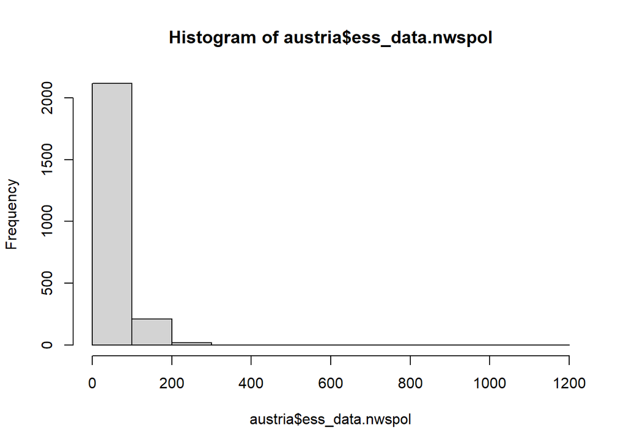

```r
hist(austria$ess_data.nwspol)
```

This is a bad histogram for many reasons, the most obvious being that we have too few bins (most of those being empty). We can make two (at least) changes to make things better:

- use more bins;
- exclude (temprorarily) any outliers.

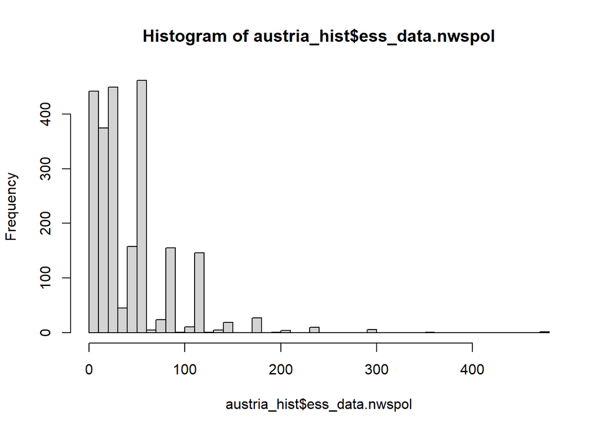

```r
austria_hist <- austria[austria$ess_data.nwspol < 600, ]
hist(austria_hist$ess_data.nwspol, breaks=50)
```

So, we can evidently infer that the distribution of our sample is not normal so, we should not have used the t-test in our case. We will explore in the future more adequate tests for populations of unknown distribution.

> As a side note, a better histogram would have included all outliers in a separate unevenly sized bin:

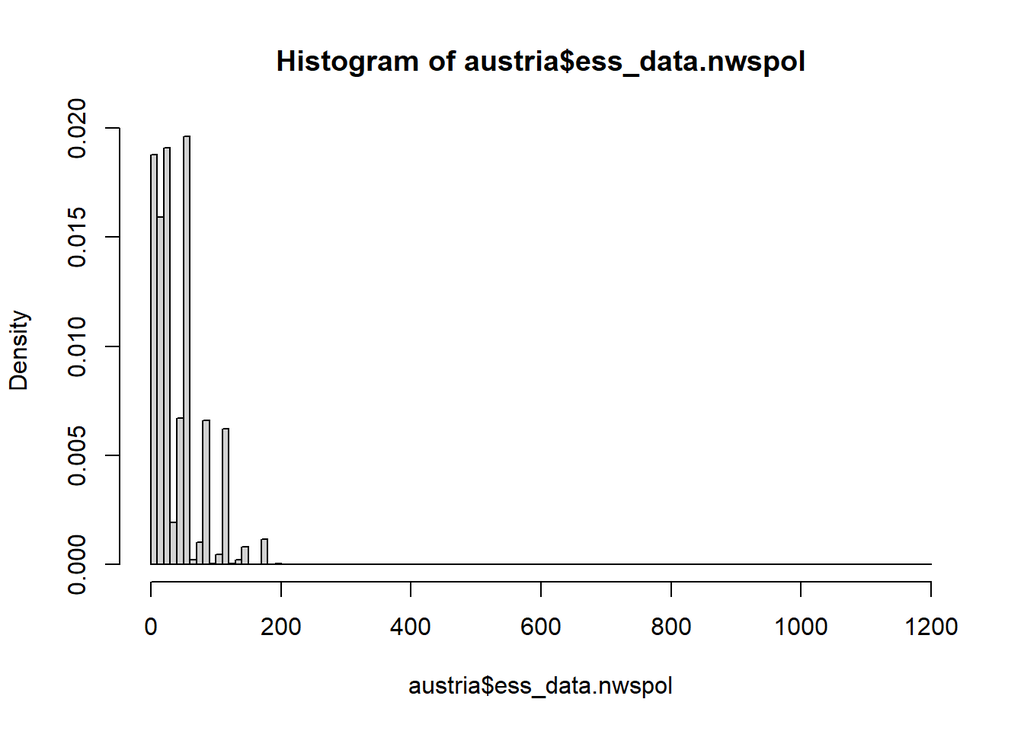

```r
hist(austria$ess_data.nwspol, breaks=c(seq(0, 200, 10), 1200))
```